# Computer lab 1: Solutions (11 Oct 2021)

Richard Wilkinson

1. Write code to compute
   $$\sum_{i=n}^{10^7} 1/n$$
   Try first writing a for loop to do the computation, and then do it without writing a loop (i.e., first form the vector $(1, 1/2, 1/3, ....)$ and then sum it). Time both methods. Which is faster?

We know this sum diverges as the number of terms tends to infinity. Write a while loop to find when the sum first exceeds 18.

```r
x<-0
t1<- system.time({
  for(n in 1:10^7){
  x<-x+1/n
  }
  })
print(x)
```

```
## [1] 16.69531
```

```r
t2 <- system.time({
  x2=sum(1/seq(1,10^7,1))
})
print(x2)
```

```
## [1] 16.69531
```

```r
print(t1)
```

```
##    user  system elapsed
##   0.172   0.001   0.173
```

```r
print(t2)
```

```
##    user  system elapsed
##   0.198   0.042   0.240
```

```r
x<-0
n<-1
while(x<18){
  x<-x+1/n
  n<-n+1
  #if(n %% 10^6==0) print(c(x,n))
  }

print(n)
```

```
## [1] 36865413
```

2. Consider the Branin function.

$$f(\mathbf{x}) = a (x_2 - b x_1^2 + cx_1 - r)^2+ s(1-t)\cos(x_1)+s \mbox{ for } x_1\in [-5,10], x_2 \in [0, 15]$$

The parameters $a, b, c, r, s, t$ are fixed constants, which have default values $a = 1, b = \frac{5.1}{4\pi^2}, c = \frac{5}{\pi}, r = 6, s = 10$ and $t = \frac{1} {8\pi}$.

```r
branin <- function(x, a=1,b=5.1/(4*pi*2), c=5/pi, r=6, s=10, t=1/(8*pi)){
  stopifnot(x[1]<=10, x[1]>=-5, x[2]<=15, x[2]>=0)
  out <- a *(x[2] - b* x[1]^2 + c*x[1] - r)^2+ s*(1-t)*cos(x[1])+s
  return(out)
}
```

- Plot the function over its domain.

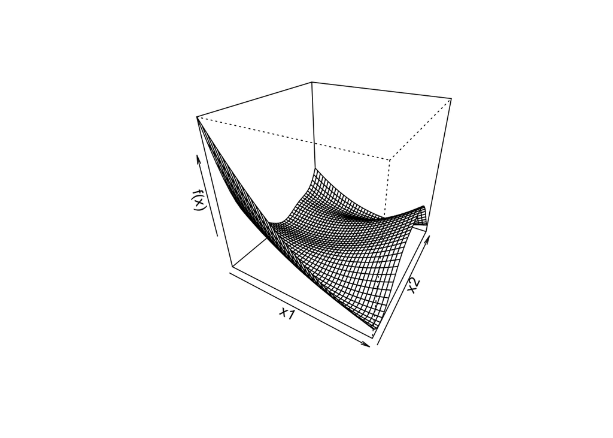

```r
library(pracma)
x1 <- seq(-5,10,length.out=40)
x2 <- seq(0,15,length.out=40)
tmp <- meshgrid(x1,x2)
z.plt<-apply(cbind(c(tmp$X), c(tmp$Y)), 1, branin)

persp(x1,x2,matrix(z.plt, nrow=dim(tmp$X)[1]), zlab='f(x)', theta=30, phi=30)
```

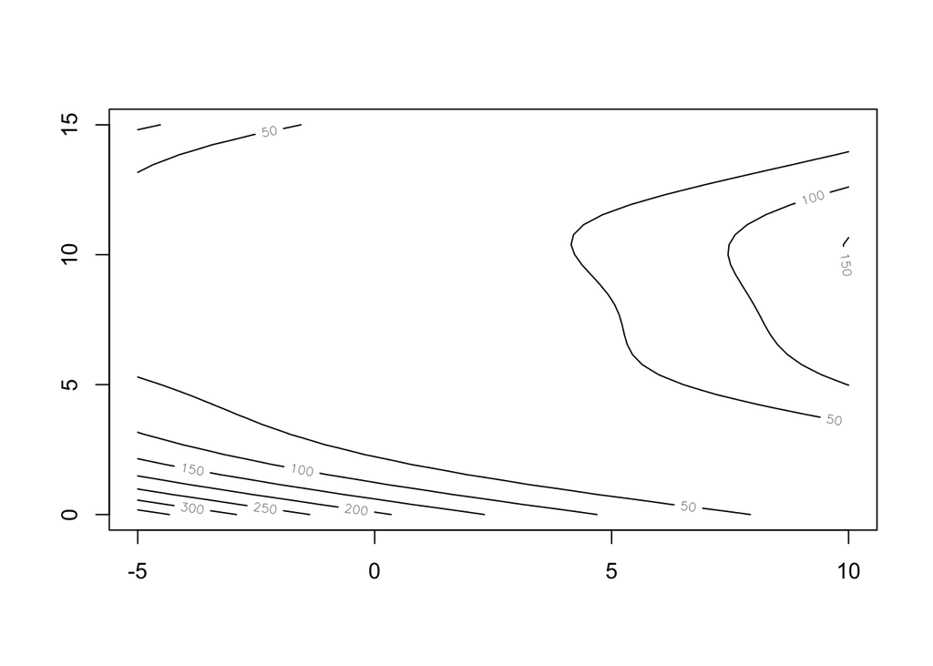

```r
contour(x1,x2,matrix(z.plt, nrow=dim(tmp$X)[1]))
```

These are just basic plots. But it is easy now to create a range of interactive plots in R that you can rotate and zoom in on. For example, see [here](https://rviews.rstudio.com/2020/12/14/plotting-surfaces-with-r/).

- Calculate (mathematically) the gradient of the function (with respect to $\mathbf{x}$), and the Hessian matrix.

$$\nabla f(\mathbf{x}) = \begin{pmatrix}2a(-2bx_1+c)(x_2-bx_1^2+cx_1-r)-s(1-t)\sin(x_1)\\
2a(x_2-bx_1^2+cx_1-r)\end{pmatrix}$$
$$\nabla^2 f(\mathbf{x}) =\begin{pmatrix}-4ab(x_2-bx_1^2+cx_1-r)+2a(-2bx_1+c)^2-s(1-t)\cos(x_1) & 2x(-2bx_1+c)\\
2x(-2bx_1+c) & 2a\end{pmatrix}$$

- We will now use a finite difference approximation to compute the gradients, which can be a useful way to check your calculation above. To approximate the first derivative of a function $g(x)$ we can use
  $$g'(x) \approx \frac{g(x+h)-g(x-h)}{2h}$$
  for small $h$. Use this approximation to approximate the gradient of $f$at $\mathbf{x}=(1,1)^\top$. What happens as $h$ gets smaller? Plot the error in this approximation vs $h$, using a log-scale for both axes. What happens if $h$ becomes too small? Why does this happen?

Demonstrate why we prefer this central difference method to the forward difference approximation
$$g'(x) \approx \frac{g(x+h)-g(x)}{h}$$

Note that if $\dim (\mathbf{x})>1$ we need to perturb one input variable at a time, e.g.,

$$\frac{\partial g}{\partial x_i}(\mathbf{x}) \approx \frac{g(\mathbf{x}+h\mathbf{e}_i)-g(\mathbf{x}-h\mathbf{e}_i)}{2h}.$$

Let’s first define the derivative we just computed

```r
grad_f <- function(x, a=1,b=5.1/(4*pi*2), c=5/pi, r=6, s=10, t=1/(8*pi)){
  stopifnot(x[1]<=10, x[1]>=-5, x[2]<=15, x[2]>=0)
  out1 <- 2*a*(-2*b*x[1]+c)*(x[2]-b*x[1]^2+c*x[1]-r)-s*(1-t)*sin(x[1])
  out2 <-  2*a*(x[2]-b*x[1]^2+c*x[1]-r)
  return(c(out1,out2))
}
grad_f(c(1,1))
```

```
## [1] -16.643941  -7.222746
```

```r
Hessian <- function(x, a=1,b=5.1/(4*pi*2), c=5/pi, r=6, s=10, t=1/(8*pi)){
  stopifnot(x[1]<=10, x[1]>=-5, x[2]<=15, x[2]>=0)
  d11 <- -4*a*b*(x[2]-b*x[1]^2+c*x[1]-r)+2*a*(-2*b*x[1]+c)^2-s*(1-t)*cos(x[1])
  d12 <- 2*x[1]*(-2*b*x[1]+c)
  d22<-2*a
return(matrix(c(d11,d12,d12,d22), nr=2))
}
```

```r
x=c(1,1)
eps<-10^-5

central_diff <- function(x, eps){
  d1 <- (branin(x+c(eps,0))-branin(x+c(-eps,0)))/(2*eps)
  d2 <- (branin(x+c(0,eps))-branin(x+c(0,-eps)))/(2*eps)
  return(c(d1,d2))
}

central_diff(x,eps)
```

```
## [1] -16.643941  -7.222746
```

```r
grad_f(x)
```

```
## [1] -16.643941  -7.222746
```

As eps gets smaller we get a more accurate approximation, but if we let eps be too small numerical underflow can occur.

```r
central_error <- function(x, eps){
  sqrt(sum((central_diff(x,eps)-grad_f(x))^2))
}

central_error(x, 10^-15)
```

```
## [1] 1.125758
```

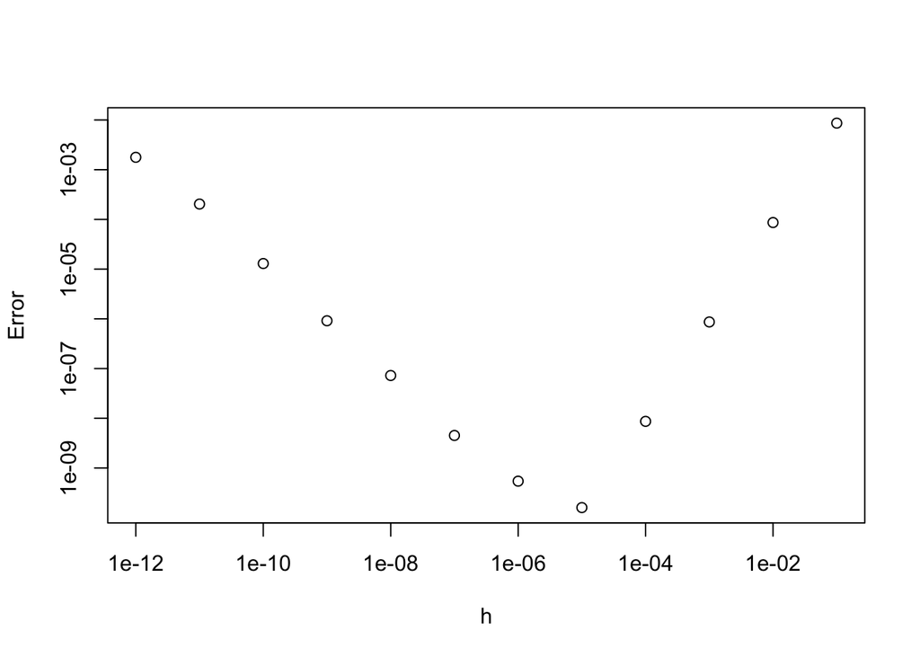

```r
eps.vals <- 10^(-seq(1,12))
errors <- sapply(eps.vals, function(e) central_error(x,e))
plot(eps.vals, errors, log='xy', xlab='h', ylab='Error')
```

If we compare with the forward difference method, we can see we get a better error rate with the central difference method.

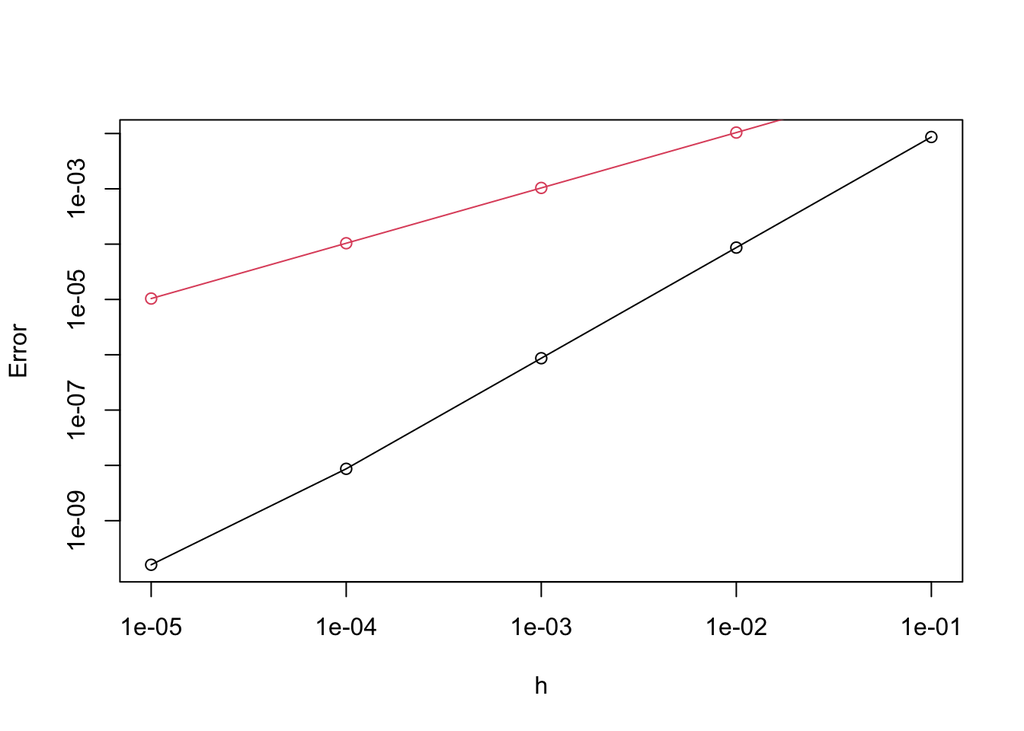

```r
fwd_diff <- function(x, eps){
  d1 <- (branin(x+c(eps,0))-branin(x))/eps
  d2 <- (branin(x+c(0,eps))-branin(x))/eps
  return(c(d1,d2))
}

fwd_error <- function(x, eps){
  sqrt(sum((fwd_diff(x,eps)-grad_f(x))^2))

}


eps.vals <- 10^(-seq(1,5))
cent.errors <- sapply(eps.vals, function(e) central_error(x,e))
fwd.errors <- sapply(eps.vals, function(e) fwd_error(x,e))

plot(eps.vals, cent.errors, log='xy', xlab='h', ylab='Error')
lines(eps.vals, cent.errors, col=1)

points(eps.vals, fwd.errors, col=2)
lines(eps.vals, fwd.errors, col=2)
```

- The numDeriv package in R has functions to compute numerical estimates of second derivatives. Install this package and use it to check your calculations.

```r
library(numDeriv)
numDeriv::grad(branin,x)
```

```
## [1] -16.643941  -7.222746
```

```r
grad_f(x)
```

```
## [1] -16.643941  -7.222746
```

```r
numDeriv::hessian(branin,x)
```

```
##           [,1]     [,2]
## [1,] 0.5550621 2.371409
## [2,] 2.3714087 2.000000
```

```r
Hessian(x)
```

```
##           [,1]     [,2]
## [1,] 0.5550621 2.371409
## [2,] 2.3714087 2.000000
```

- Use one of the default optimization methods in your language of choice to find the minima of $f$. In R, you can use the command `optim`.

```r
optim(c(-3,3), branin)
```

```
## $par
## [1] 3.141640 3.003276
##
## $value
## [1] 0.3978876
##
## $counts
## function gradient
##       67       NA
##
## $convergence
## [1] 0
##
## $message
## NULL
```

3. Create a random $5 \times 5$ matrix, $A$ say. Write a function to evaluate the quadratic form
   $$f(\mathbf{x})=\mathbf{x}^\top A\mathbf{x}.$$
   Compute the gradient vector and Hessian matrix using numerical approximation, and check your answer against the true answer derived in the lecture notes.

We showed in the notes that
$$\nabla f(\mathbf{x}) = (A+A^\top)\mathbf{x}\qquad \nabla^2 f(\mathbf{x})=A+A^\top.$$
Let’s check this.

```r
A<- matrix(rnorm(25), nr=5)
f<-function(x){
  t(x)%*%A%*%x
}

# lets use x=1:5 as a test point
x=1:5
numDeriv::grad(f, x)
```

```
## [1]  -1.723279  15.210894  -8.900258   3.625427 -14.943985
```

```r
(A+t(A))%*%x # the gradient we computed in lectures
```

```
##            [,1]
## [1,]  -1.723279
## [2,]  15.210894
## [3,]  -8.900258
## [4,]   3.625427
## [5,] -14.943985
```

```r
numDeriv::hessian(f,x)
```

```
##            [,1]       [,2]       [,3]       [,4]       [,5]
## [1,] -5.5604395 -1.3756876 -0.1699911  2.1447060 -0.2960629
## [2,] -1.3756876  2.0667096  1.8614115 -0.7923756  2.0076861
## [3,] -0.1699911  1.8614115 -3.0667100  2.4241423 -2.5899058
## [4,]  2.1447060 -0.7923756  2.4241423  1.1300031 -1.7453933
## [5,] -0.2960629  2.0076861 -2.5899058 -1.7453933 -0.7824007
```

```r
A+t(A)
```

```
##            [,1]       [,2]       [,3]       [,4]       [,5]
## [1,] -5.5604395 -1.3756876 -0.1699911  2.1447060 -0.2960629
## [2,] -1.3756876  2.0667096  1.8614115 -0.7923756  2.0076861
## [3,] -0.1699911  1.8614115 -3.0667100  2.4241423 -2.5899058
## [4,]  2.1447060 -0.7923756  2.4241423  1.1300031 -1.7453933
## [5,] -0.2960629  2.0076861 -2.5899058 -1.7453933 -0.7824007
```